# Homework_3

Rutwik Guntoorkar - rutwik.guntoorkar@rutgers.edu

9/22/2022

```r
library(fpp)
library(fpp2)
data()
table(debitcards)
```

[output not shown]

```r
head(debitcards)
```

```
##        Jan   Feb   Mar   Apr   May   Jun
## 2000 7.204 7.335 7.812 7.413 9.136 8.725
```

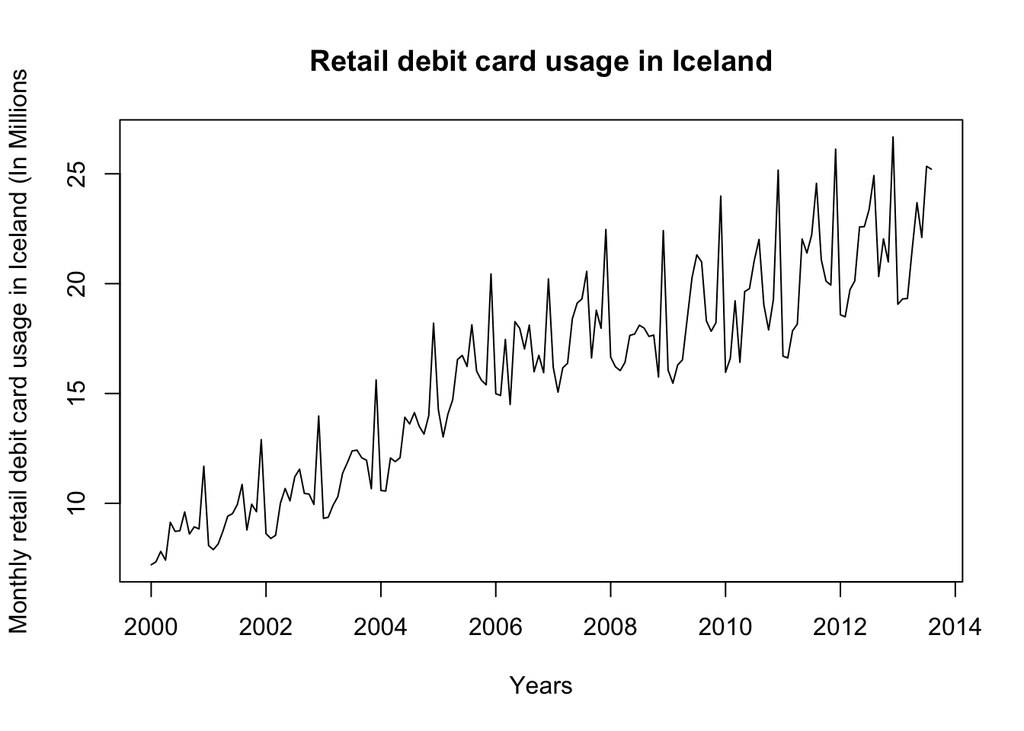

```r
plot(debitcards,main = "Retail debit card usage in Iceland", xlab = "Years", ylab="Monthly retail debit card usage in Iceland (In Millions")
```

#Conclusion : •Plot shows upper trend pattern in usage data. •We can see a small seasonality going up every year. •After studying this plot we can infer that: ∙Acf plot should have significant values. ∙There might be a wave visual of the correlation depicting the seasonal change in the data.

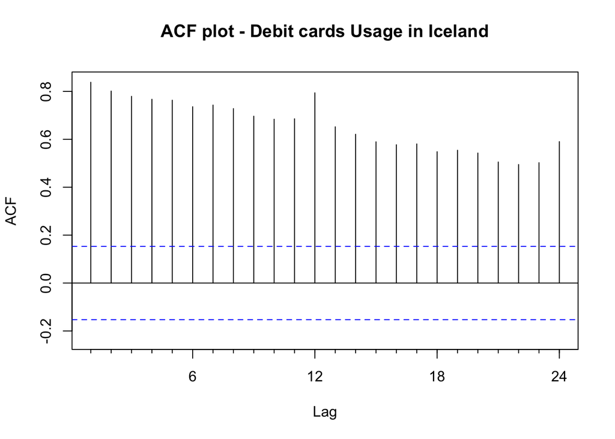

```r
Acf(debitcards, main = "ACF plot - Debit cards Usage in Iceland")
```

#Conclusion : •This shows that the historic data has significant impact on the preceding data. •Predicted small seasonality can be seen in ACF plot

```r
practice <- HoltWinters(debitcards)
attributes(practice)
```

```
## $names
## [1] "fitted"       "x"            "alpha"        "beta"         "gamma"
## [6] "coefficients" "seasonal"     "SSE"          "call"
##
## $class
## [1] "HoltWinters"
```

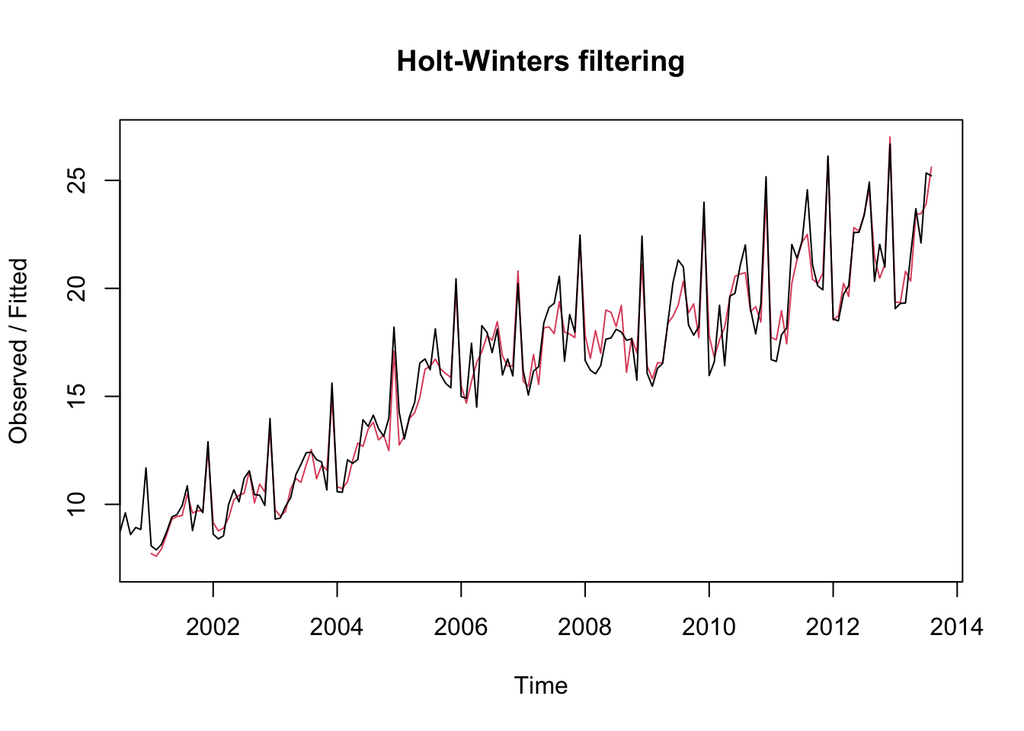

```r
plot(practice)
```

#Conclusion : •As seen above Holt winters algorithm is deviating at multiple points. •Which indicates tuning must be done for alpha, beta, gamma values.

```r
practice_f <- forecast(practice)
attributes(practice_f)
```

```
## $names
##  [1] "method"    "model"     "level"     "mean"      "lower"     "upper"
##  [7] "x"         "series"    "fitted"    "residuals"
##
## $class
## [1] "forecast"
```

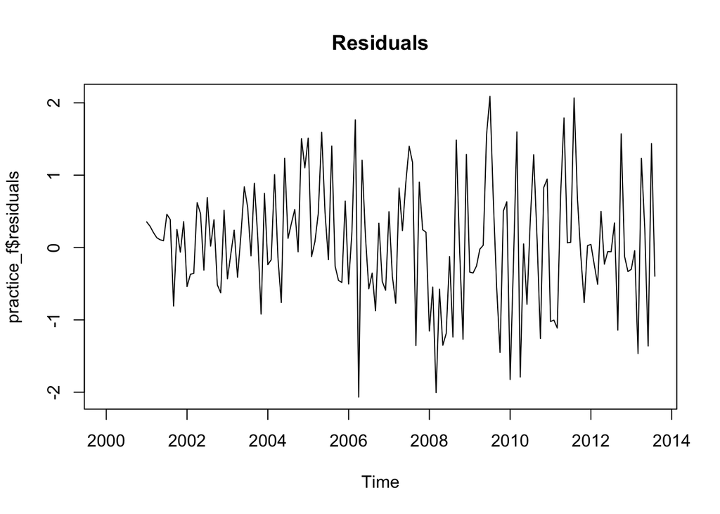

```r
plot(practice_f$residuals, main = "Residuals")
```

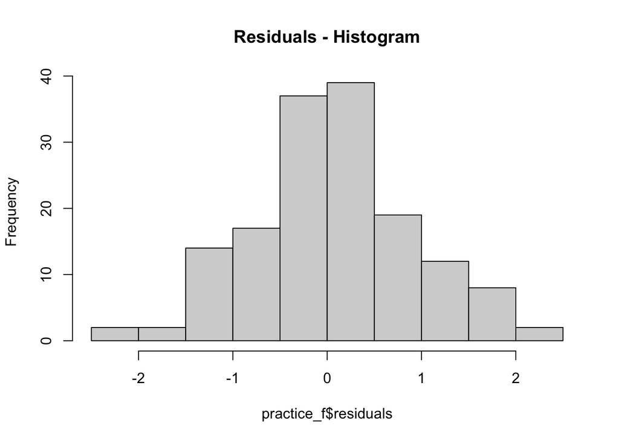

```r
hist(practice_f$residuals, main = "Residuals - Histogram")
```

#Conclusion : The histogrm plot shows normal distribution for residual

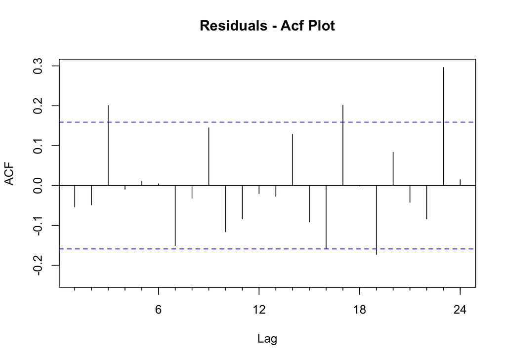

```r
Acf(practice_f$residuals, main = "Residuals - Acf Plot")
```

#Conclusion : As there are four lines crossing confidence internal line, there is significant difference and the residuals can be predictable.

```r
accuracy(practice_f)
```

```
##                      ME      RMSE       MAE       MPE     MAPE      MASE
## Training set 0.06827408 0.8489168 0.6598678 0.2532669 4.074923 0.5150002
##                     ACF1
## Training set -0.05379126
```